# Student activity 3: instructor solution

Worked analysis and teaching notes for boxplots_data.csv

Livio Finos, University of Padova

```r
knitr::opts_chunk$set(echo = TRUE, message = FALSE, warning = TRUE,
                     fig.width = 8, fig.height = 5, fig.align = "center",
                     dpi = 120, comment = "#>")
options(width = 90)
# All executed examples use base R. Only knitr and rmarkdown are needed to knit.
blue <- "#0072B2"
orange <- "#D55E00"
green <- "#009E73"
purple <- "#CC79A7"

# Use exactly the same hinges and fences as base R's boxplot().
# Restrict this teaching helper to finite numeric data.
bp_info <- function(z) {
  stopifnot(is.numeric(z), length(z) >= 2L, all(is.finite(z)))
  s <- boxplot.stats(z, coef = 1.5)$stats
  spread <- s[4] - s[2]
  lower <- s[2] - 1.5 * spread
  upper <- s[4] + 1.5 * spread
  list(stats = s, iqr = spread, lower = lower, upper = upper,
       flag = z < lower | z > upper)
}

# Overlay observations, with jitter only along the categorical axis.
# exclude_points reserves selected cases for a separate labelled point layer;
# it does not exclude them from the boxplot summary or axis limits.
# The explicit ylim preserves the full range when outline = FALSE.
box_points <- function(z, main = "", ylab = "Value", col = blue,
                       exclude_points = integer(0)) {
  boxplot(z, outline = FALSE, ylim = range(z), xlim = c(0.6, 1.4),
          xaxt = "n", ylab = ylab, main = main, col = "grey95",
          border = "grey20", boxwex = 0.3, lwd=2)
  keep <- !(seq_along(z) %in% exclude_points)
  points(jitter(rep(1, sum(keep)), amount = 0.08), z[keep],
         pch = 16, cex = 0.65, col = adjustcolor(col, alpha.f = 0.5))
}
```

# 1 Instructor use

This document contains the worked solution to `06_student_activity3_boxplots.Rmd`. Distribute that activity and `data/boxplots_data.csv` to students. Keep this solution separate until the discussion or release it afterwards.

Place this Rmd beside the student activity, with the CSV in their shared `data` subfolder. The analysis below imports that file, so both versions use the same observations. Knit with `knitr` and `rmarkdown`; all plots here use base R. Pandoc is required and is bundled with RStudio.

The student activity uses a fictional sensor-calibration context: `x` is a reference input level and `y` is a sensor reading, in arbitrary units. Each row is one simulated calibration run. Row order is not a time sequence. The data-generation equation and intended roles of A, B and C below belong to the solution and are deliberately absent from the student handout.

| Student task | Corresponding worked analysis |
| --- | --- |
| Step 1: inspect and plan | Import checks and dataset construction |
| Step 2: response alone | First look: the marginal distribution of Y |
| Step 3: add X | Second look: Y against X, with a fitted line |
| Step 4: residuals | Third look: residuals |
| Step 5: diagnostics | A bridge to influential observations |
| Step 6: case deletion | Observe influence directly by leaving one case out |
| Step 7: modified A | What happens if the same high-leverage point moves off the line? |

Assess the connection between evidence and interpretation, not just the code. The report should retain all observations in its initial fit, identify cases by `id`, compare predictions on a common set of predictor values, and distinguish sensitivity analysis from a decision to delete measurements.

# 2 Add an explanatory variable: unusual compared with what?

## 2.1 Dataset construction and three informative cases

Suppose $Y$ is a response and $X$ is a predictor. For most observations we simulate

$$Y_i=10+3X_i+\varepsilon_i,\qquad
\varepsilon_i\sim N(0,1.2^2),$$

with $X$ values between 0 and 10. We then add three **deliberately constructed** cases. This is a teaching dataset, not a representative sample from a single uncontaminated model.

[output not shown]

For now, conceal this table when presenting the first graph and ask students to identify cases using only the response.

```r
set.seed(8675309)
background <- data.frame(id = sprintf("R%02d", 1:80),
                         x = seq(0, 10, length.out = 80))
background$y <- 10 + 3 * background$x + rnorm(80, sd = 1.2)
special <- data.frame(id = c("A", "B", "C"),
                      x = c(18, 5, 1)+runif(3), y = c(64, 65, 30)+runif(3))
dat <- rbind(background, special)
is_special <- dat$id %in% c("A", "B", "C")
special_rows <- which(is_special)
case_col <- c(A = blue, B = orange, C = green)
write.csv(dat,file="data/boxplots_data.csv",row.names = FALSE)

y_info <- bp_info(dat$y)
dat$marginal_flag <- y_info$flag
```

```r
data_path <- file.path("data", "boxplots_data.csv")
if (!file.exists(data_path)) {
  stop("Place boxplots_data.csv in the data folder next to this Rmd.")
}
dat_raw <- read.csv(data_path, stringsAsFactors = FALSE)
stopifnot(identical(names(dat_raw), c("id", "x", "y")),
          nrow(dat_raw) == 83L, !anyNA(dat_raw),
          !anyDuplicated(dat_raw$id),
          is.numeric(dat_raw$x), is.numeric(dat_raw$y),
          all(is.finite(dat_raw$x)), all(is.finite(dat_raw$y)),
          all(c("A", "B", "C") %in% dat_raw$id))
dat <- dat_raw
nrow(dat)
```

```
#> [1] 83
```

```r
summary(dat[c("x", "y")])
```

```
#>        x                y
#>  Min.   : 0.000   Min.   : 8.804
#>  1st Qu.: 2.468   1st Qu.:18.045
#>  Median : 5.063   Median :25.476
#>  Mean   : 5.129   Mean   :26.038
#>  3rd Qu.: 7.532   3rd Qu.:33.321
#>  Max.   :18.534   Max.   :65.729
```

```r
is_special <- dat$id %in% c("A", "B", "C")
special_rows <- match(c("A", "B", "C"), dat$id)
case_col <- c(A = blue, B = orange, C = green)
y_info <- bp_info(dat$y)
dat$marginal_flag <- y_info$flag
```

## 2.2 First look: the marginal distribution of Y

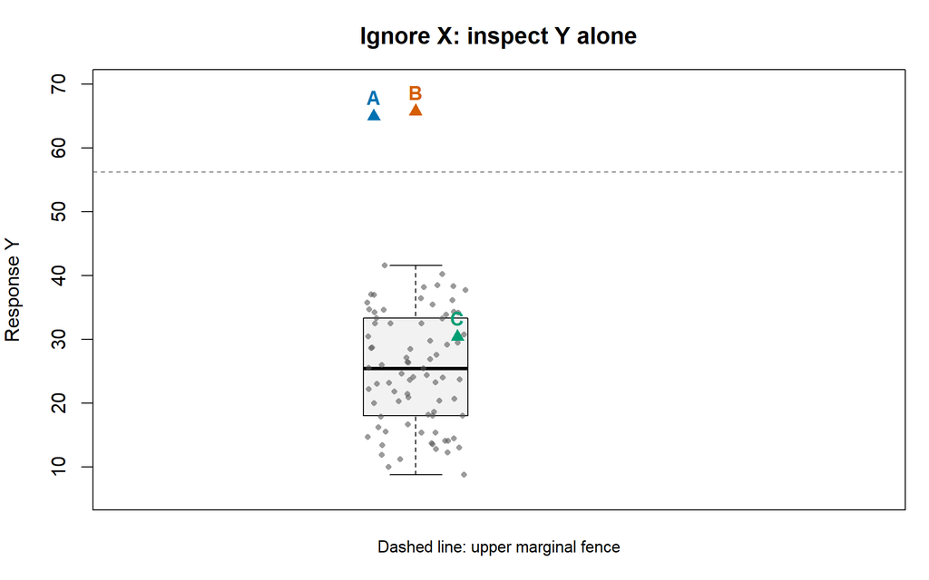

A and B are marginally extreme responses; C lies within the central range of Y.

```r
set.seed(4242)
local({
  par(mar = c(3, 4, 3, 1))
  boxplot(dat$y, outline = FALSE, ylim = range(dat$y) + c(-3, 4),
          xlim = c(0.65, 1.55), boxwex = 0.25, xaxt = "n",
          ylab = "Response Y", col = "grey95", main = "Ignore X: inspect Y alone")
  points(jitter(rep(1, sum(!is_special)), amount = 0.06), dat$y[!is_special],
         pch = 16, cex = 0.65, col = adjustcolor("grey35", alpha.f = 0.6))
  # Separate A and B horizontally so their nearby responses remain readable.
  sx <- c(0.95, 1, 1.05)
  points(sx, dat$y[special_rows], pch = 17, cex = 1.2, col = case_col)
  text(sx, dat$y[special_rows], labels = dat$id[special_rows], pos = 3,
       col = case_col, font = 2)
  abline(h = y_info$upper, lty = 2, col = "grey45")
  mtext("Dashed line: upper marginal fence", side = 1, line = 1, cex = 0.85)
})
```

A and B are flagged, whereas C is not. But this view compares each response with *all* responses, regardless of its predictor value. It discards information that might explain why responses differ.

## 2.3 Second look: Y against X, with a fitted line

Fit ordinary least squares using **all** observations, including A, B and C. We do not first remove the points we want to investigate.

```r
fit <- lm(y ~ x, data = dat)
coef(fit)
```

```
#> (Intercept)           x
#>   11.264738    2.880609
```

```r
dat$fitted <- fitted(fit)
dat$residual <- resid(fit)
```

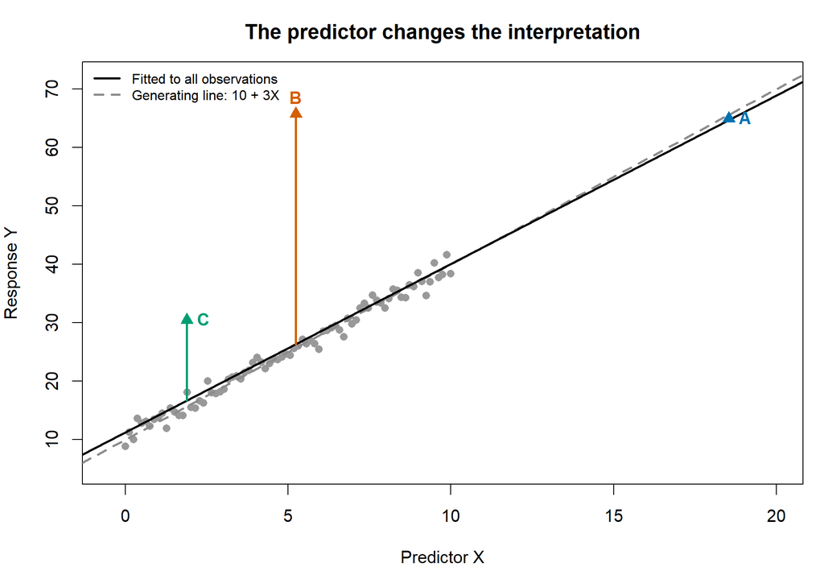

Vertical segments are residuals from the fitted line. The generating line is shown because it is known in this simulation.

```r
local({
  par(mar = c(4, 4, 3, 1))
  plot(y ~ x, data = dat, pch = 16, col = "grey60",
       xlim = c(-0.5, 20), ylim = c(5, 72),
       xlab = "Predictor X", ylab = "Response Y",
       main = "The predictor changes the interpretation")
  abline(a = 10, b = 3, col = "grey55", lty = 2, lwd = 2)
  abline(fit, col = "black", lwd = 2)
  with(dat[special_rows, ], segments(x, fitted, x, y, col = case_col, lwd = 2))
  points(dat$x[special_rows], dat$y[special_rows], pch = 17,
         cex = 1.3, col = case_col)
  text(dat$x[special_rows], dat$y[special_rows],
       labels = dat$id[special_rows], pos = c(4, 3, 4), col = case_col, font = 2)
  legend("topleft", c("Fitted to all observations", "Generating line: 10 + 3X"),
         col = c("black", "grey55"), lty = c(1, 2), lwd = 2, bty = "n", cex = 0.8)
})
```

The fitted line need not equal the generating line: random errors and the inserted cases affect its coefficients. In real data, we do not know the true line and cannot establish model compatibility simply by drawing one. Also, A extends beyond the background range of $X$: accepting the linear relationship there is a substantive assumption.

## 2.4 Third look: residuals

The residual for observation $i$ is its vertical distance from the fitted line:

$$e_i=y_i-\widehat y_i,
\qquad \widehat y_i=\widehat\beta_0+\widehat\beta_1x_i.$$

A response boxplot asks, **“Is this response unusual among all responses?”** A residual display asks, **“Is this response unusual relative to what the fitted model predicts at this predictor value?”**

```r
r_info <- bp_info(dat$residual)
dat$residual_flag <- r_info$flag
case_table <- dat[is_special,
                  c("id", "x", "y", "fitted", "residual", "marginal_flag", "residual_flag")]
knitr::kable(case_table, digits = 3, row.names = FALSE)
```

| id | x | y | fitted | residual | marginal_flag | residual_flag |
| --- | --- | --- | --- | --- | --- | --- |
| A | 18.534 | 64.957 | 64.655 | 0.303 | TRUE | FALSE |
| B | 5.241 | 65.729 | 26.363 | 39.366 | TRUE | TRUE |
| C | 1.895 | 30.419 | 16.722 | 13.696 | FALSE | TRUE |

```r
# These assertions check the intended pedagogical contrast.
stopifnot(identical(dat$marginal_flag[special_rows], c(TRUE, TRUE, FALSE)),
          identical(dat$residual_flag[special_rows], c(FALSE, TRUE, TRUE)))
```

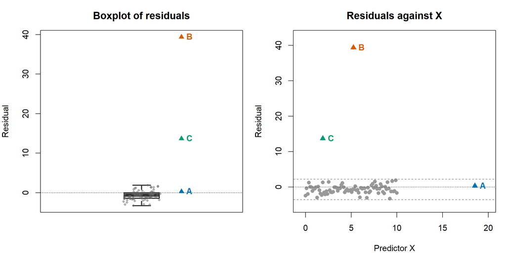

B and C have large residuals. A is near the fitted relationship despite its large response.

| Case | Flagged in the response boxplot? | Flagged in the residual boxplot? | Interpretation |
| --- | --- | --- | --- |
| A | Yes | No | An extreme response explained by an extreme predictor. |
| B | Yes | Yes | An extreme response that remains unusual given its predictor. |
| C | No | Yes | A marginally ordinary response that the fitted relationship does not explain. |

```r
set.seed(9393)
local({
  par(mfrow = c(1, 2), mar = c(4, 4, 3, 1))
  box_points(dat$residual, main = "Boxplot of residuals", ylab = "Residual",
             col = "grey40", exclude_points = special_rows)
  abline(h = 0, lty = 3)
  points(rep(1.17, 3), dat$residual[special_rows], pch = 17, col = case_col, cex = 1.1)
  text(rep(1.17, 3), dat$residual[special_rows], labels = dat$id[special_rows],
       pos = 4, col = case_col, font = 2)
  plot(residual ~ x, data = dat, pch = 16, col = "grey60",
       xlim = c(-0.5, 20), ylim = range(dat$residual) + c(-2, 3),
       xlab = "Predictor X", ylab = "Residual", main = "Residuals against X")
  abline(h = 0, lty = 3)
  abline(h = c(r_info$lower, r_info$upper), lty = 2, col = "grey45")
  points(dat$x[special_rows], dat$residual[special_rows], pch = 17, col = case_col, cex = 1.2)
  text(dat$x[special_rows], dat$residual[special_rows], labels = dat$id[special_rows],
       pos = 4, col = case_col, font = 2)
})
```

Some background observations may also be flagged by a residual boxplot. The same caution about automatic outlier rules still applies.

**A diagnostic limitation.** Residuals are not independent copies of the model errors. Even under the standard constant-variance linear model, $\operatorname{Var}(e_i\mid X)=\sigma^2(1-h_{ii})$, where $h_{ii}$ is leverage. Thus a residual boxplot is an exploratory aid, not a calibrated formal outlier test. Residual-versus-predictor or residual-versus-fitted plots also reveal curvature and changing spread that a residual boxplot hides.

## 2.5 A bridge to influential observations

Three different questions require three different concepts:

| Concept | Question | Useful R quantity |
| --- | --- | --- |
| Residual size | Is the response far from the fitted relationship? | `resid(fit)`, `rstandard(fit)`, `rstudent(fit)` |
| Leverage | Is the predictor configuration unusual? | `hatvalues(fit)` |
| Influence | How much does the fitted model change when this case is omitted? | `cooks.distance(fit)`, case-deletion fits |

With an intercept and one predictor,

$$h_{ii}=\frac{1}{n}+\frac{(x_i-\bar x)^2}{\sum_j(x_j-\bar x)^2}.$$

Leverage depends on $X$, not on $Y$. A has high leverage because its predictor value is far from the others. High leverage means **potential** to affect the fit; a high-leverage point close to the fitted line need not substantially change the estimated coefficients when omitted. It can still affect their precision and anchor the range over which a line is fitted.

Cook’s distance combines residual size and leverage. For this regression, with $p=2$ estimated coefficients and $s^2$ the residual mean square,

$$D_i=\frac{e_i^2}{p s^2}\frac{h_{ii}}{(1-h_{ii})^2}.$$

```r
dat$leverage <- hatvalues(fit)
dat$standardized_residual <- rstandard(fit)
dat$studentized_residual <- rstudent(fit)
dat$cook <- cooks.distance(fit)
knitr::kable(dat[is_special, c("id", "residual", "leverage",
                              "standardized_residual", "studentized_residual", "cook")],
             digits = 3, row.names = FALSE)
```

| id | residual | leverage | standardized_residual | studentized_residual | cook |
| --- | --- | --- | --- | --- | --- |
| A | 0.303 | 0.217 | 0.071 | 0.071 | 0.001 |
| B | 39.366 | 0.012 | 8.239 | 20.338 | 0.414 |
| C | 13.696 | 0.024 | 2.884 | 3.026 | 0.102 |

Standardized residuals use the overall residual scale and the leverage adjustment. Externally studentized residuals (`rstudent`) estimate the scale with the case omitted. They help with comparability, but neither a universal cutoff nor automatic deletion follows from this table. Several unusual cases can distort the fit and inflate the estimated error scale, partially masking one another.

### 2.5.1 Observe influence directly by leaving one case out

```r
full_coef <- coef(fit)
leave_out <- do.call(rbind, lapply(c("A", "B", "C"), function(label) {
  fit_minus <- lm(y ~ x, data = dat[dat$id != label, ])
  data.frame(Omitted = label,
             Intercept = unname(coef(fit_minus)[1]),
             Slope = unname(coef(fit_minus)[2]),
             Change_intercept = unname(coef(fit_minus)[1] - full_coef[1]),
             Change_slope = unname(coef(fit_minus)[2] - full_coef[2]),
             Max_fitted_change = max(abs(predict(fit_minus, newdata = dat) - fitted(fit))))
}))
knitr::kable(leave_out, digits = 4, row.names = FALSE)
```

| Omitted | Intercept | Slope | Change_intercept | Change_slope | Max_fitted_change |
| --- | --- | --- | --- | --- | --- |
| A | 11.2905 | 2.8747 | 0.0257 | -0.0059 | 0.0841 |
| B | 10.8110 | 2.8755 | -0.4537 | -0.0051 | 0.5490 |
| C | 10.8297 | 2.9325 | -0.4351 | 0.0519 | 0.5262 |

This is a sensitivity analysis, not a recommendation to discard observations. The last column compares predictions at the observed predictor values, including the location of the omitted case. For A, that location is outside the predictor range remaining after deletion.

### 2.5.2 What happens if the same high-leverage point moves off the line?

```r
dat_shift <- dat
iA <- which(dat$id == "A")
dat_shift$y[iA] <- 89
fit_shift <- lm(y ~ x, data = dat_shift)
fit_no_A <- lm(y ~ x, data = dat[dat$id != "A", ])

compare_A <- data.frame(
  Scenario = c("A on the generating line", "A moved upwards by 25"),
  Leverage_A = c(hatvalues(fit)[iA], hatvalues(fit_shift)[iA]),
  Residual_A = c(resid(fit)[iA], resid(fit_shift)[iA]),
  Cook_A = c(cooks.distance(fit)[iA], cooks.distance(fit_shift)[iA]),
  Fitted_slope = c(coef(fit)[2], coef(fit_shift)[2]),
  Slope_without_A = rep(unname(coef(fit_no_A)[2]), 2)
)
knitr::kable(compare_A, digits = 4, row.names = FALSE)
```

| Scenario | Leverage_A | Residual_A | Cook_A | Fitted_slope | Slope_without_A |
| --- | --- | --- | --- | --- | --- |
| A on the generating line | 0.2174 | 0.3028 | 0.0007 | 2.8806 | 2.8747 |
| A moved upwards by 25 | 0.2174 | 19.1179 | 2.2469 | 3.2489 | 2.8747 |

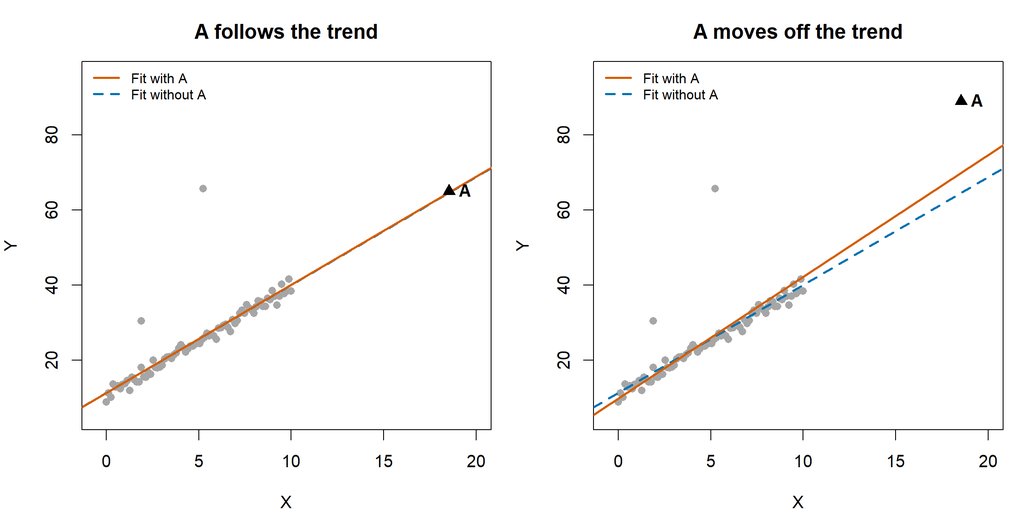

The same predictor value gives the same leverage in both panels. Moving its response away from the trend increases A’s influence.

```r
local({
  par(mfrow = c(1, 2), mar = c(4, 4, 3, 1))
  data_list <- list(dat, dat_shift)
  fit_list <- list(fit, fit_shift)
  for (j in 1:2) {
    dd <- data_list[[j]]
    plot(y ~ x, data = dd, pch = 16, col = "grey65",
         xlim = c(-0.5, 20), ylim = c(5, 96), xlab = "X", ylab = "Y",
         main = c("A follows the trend", "A moves off the trend")[j])
    abline(fit_no_A, col = blue, lwd = 2, lty = 2)
    abline(fit_list[[j]], col = orange, lwd = 2)
    points(dd$x[iA], dd$y[iA], pch = 17, cex = 1.3, col = "black")
    text(dd$x[iA], dd$y[iA], "A", pos = 4, font = 2)
    legend("topleft", c("Fit with A", "Fit without A"),
           col = c(orange, blue), lty = c(1, 2), lwd = 2, bty = "n", cex = 0.8)
  }
})
```

A’s leverage stays exactly the same because none of the predictor values change. Its residual and Cook’s distance increase, and the fitted line rotates towards its new response. A high-leverage observation can pull the line toward itself, making its residual smaller than the deviation from the relationship supported by the remaining data. Looking only for the largest raw residual can therefore miss an influential case.

**Questions for the next unit on linear models:** Is the mean relationship really linear? Does the conditional variance change with $X$? Are there missing predictors or groups? Are the unusual measurements correct? How sensitive are scientific conclusions to individual observations?

# 3 Additional discussion prompts

Items 1–6 below review the distribution examples from Unit 05. They are optional extensions, rather than extra required analyses of the calibration CSV. Items 7–9 relate directly to the regression activity.

1. **Anatomy.** For `c(1, 2, 3, 4, 5, 6, 7, 8, 20)`, calculate the median, box edges, IQR, fences and whiskers. Check them with `boxplot.stats()`. Why is the upper whisker not equal to the upper fence?
2. **Units.** Transform that dataset to `100 + 10*z`. Prove algebraically and verify in R that the same observations remain flagged.
3. **Sample size.** Compare samples of sizes 50 and 1000 from the same model. Distinguish predictions about the *number* of flags, their *fraction*, and the probability of *at least one* flag.
4. **Generating model.** Repeat the simulation with `rchisq(n, df = 1)` and `rchisq(n, df = 10)`. Compare simulation results with population fences. Does 1.5 times the IQR correspond to a common significance level?
5. **Transformation.** Compare a boxplot of `rchisq(1000, 2)` with a boxplot of its logarithm. Which observations change flag status? Explain why nonlinear transformations differ from changes of units.
6. **Point layers.** Modify the identical-boxplot example by plotting only the points. What does the boxplot add, and what does it hide?
7. **Conditional reasoning.** Describe A, B and C without using the word *outlier*. Refer explicitly to $Y$, $X$, and the fitted relationship.
8. **Influence.** Move A downwards instead of upwards. Compare the fitted coefficients and Cook’s distance. Does its leverage change?
9. **Model adequacy.** Generate data from `y = 10 + x^2 + error`, fit `lm(y ~ x)`, and inspect residuals against $X$. Could apparent residual anomalies reflect a poor mean model rather than a few unusual observations?

## 3.1 Brief instructor notes / suggested answers

For Exercise 1 the box edges are 3 and 7, the median is 5, the IQR is 4, and the fences are -3 and 13. The whiskers end at 1 and 8; 20 is flagged.

For Exercise 2, if $w=a+bz$ with $b>0$, then its hinges transform as $Q_{j,w}=a+bQ_{j,z}$ and its IQR becomes $b\operatorname{IQR}_z$. Consequently, $L_w=a+bL_z$ and $U_w=a+bU_z$. Thus $w_i>U_w$ if and only if $z_i>U_z$, and similarly for the lower fence.

For Exercise 3, fixed-fence expected counts grow linearly with $n$ while their expected fractions remain $p_F$. The probability of at least one flag grows with $n$. Estimated sample fences add finite-sample variability and dependence.

For Exercise 4, the population flagged percentages are approximately 7.57% for one degree of freedom and 1.93% for ten, compared with 4.81% for two. These differences occur without contamination.

For Exercise 5, logarithms do not preserve additive distances or the IQR-fence inequalities. Always report the scale on which a boxplot was computed.

For Exercises 7–8, A illustrates a marginally extreme response compatible with the conditional mean; B and C have large conditional deviations. Moving A’s response changes influence but not leverage.

For Exercise 9, systematic curvature in residuals indicates misspecification of the mean function. Declaring the observations at the ends of the range “bad data” would confuse a model limitation with a measurement problem.

# 4 Take-home messages

A boxplot summarizes a distribution; it does not validate measurements. The 1.5-IQR rule flags different proportions under different generating models, and larger datasets offer more opportunities for flags. Show the observations when feasible. When predictors are available, examine the response relative to its context: a large response can be entirely compatible with a model, and an ordinary-looking response can have a large residual. Finally, an unusual predictor, a large residual and an influential case are distinct concepts.

# 5 Data provenance and optional reproduction check

```r
set.seed(8675309, kind = "Mersenne-Twister", normal.kind = "Inversion")
background <- data.frame(id = sprintf("R%02d", 1:80),
                         x = seq(0, 10, length.out = 80))
background$y <- 10 + 3 * background$x + rnorm(80, sd = 1.2)
special <- data.frame(id = c("A", "B", "C"),
                      x = c(18, 5, 1), y = c(64, 65, 30))
regenerated <- rbind(background, special)
distributed <- dat_raw[match(regenerated$id, dat_raw$id), ]
stopifnot(identical(regenerated$id, distributed$id),
          isTRUE(all.equal(regenerated$x, distributed$x, tolerance = 1e-10)),
          isTRUE(all.equal(regenerated$y, distributed$y, tolerance = 1e-10)))
```

See R’s [random-number generation documentation](https://stat.ethz.ch/R-manual/R-devel/library/base/html/Random.html) for the default algorithms and explicit seed settings.

# 6 Sources and further reading

- R documentation: [Box Plot Statistics](https://stat.ethz.ch/R-manual/R-devel/library/grDevices/html/boxplot.stats.html). Authoritative details of base R hinges and whiskers.
- Wilke, C. O. *Fundamentals of Data Visualization*: [Visualizing many distributions at once](https://clauswilke.com/dataviz/boxplots-violins.html). Examples comparing distribution summaries and individual observations.
- ggplot2 documentation: [A box and whiskers plot](https://ggplot2.tidyverse.org/reference/geom_boxplot.html). Quartile conventions and point-overlay options.
- R documentation: [Regression Deletion Diagnostics](https://stat.ethz.ch/R-manual/R-devel/library/stats/html/influence.measures.html). Definitions and functions for residual, leverage and influence diagnostics.

The regression analyses use the distributed teaching CSV. Its construction and optional reproduction check are documented above.

> **Note on AI assistance**

> These teaching materials were prepared with assistance from ChatGPT (OpenAI) in drafting explanations, developing examples, and generating R code. The author retains responsibility for the final content.